# NYPD Shooting Incident Data (Historic)

Peter Laliberte

2023-01-01

# Question of Interest

How has the NYPD Shooting Incident changed over time between the different boroughs in New York? Due to the limited time for this project, that will be the only focus of this report.

# Setting Up

The first thing I like to do when setting up a new R Markdown document (after you know what questions you want to answer) is to setup the libraries that you want to use and then make sure you have access to the data that you are going to be using.

- I will be using the libraries that are included in tidyverse.
- The data will be the *[NYPD Shooting Incident Data (Historic)](https://data.gov/)* data set from data.gov. This data is provided by each precinct and will list the reported incidents where there was a police shooting from Jan 1, 2006 - Dec 31, 2021.

```r
library(tidyverse)

url <- "https://data.cityofnewyork.us/api/views/833y-fsy8/rows.csv?accessType=DOWNLOAD"
nypd1 <- read.csv(url)
```

# Tidy & Transform Data

Once I have the data loaded, I like to do some basic examinations of it.

- First I will take a look at the data with the view() function. This will open a new tab with the data displayed in a tabular format. Other ways to do this is the head() and tail functions to get the first few rows, or last rows.
- Then I like to use the glimpse() function. This function will give me the number of rows and columns in the data set. The column names are also listed with this function along with the type of data each column holds. Lastly this will show you some of the data in the columns..
- Next I will use the summary() function so I can get some information on each feature of the data set.

```r
view(nypd1)
glimpse(nypd1)
```

```
## Rows: 25,596
## Columns: 19
## $ INCIDENT_KEY            <int> 236168668, 231008085, 230717903, 237712309, 22…
## $ OCCUR_DATE              <chr> "11/11/2021", "07/16/2021", "07/11/2021", "12/…
## $ OCCUR_TIME              <chr> "15:04:00", "22:05:00", "01:09:00", "13:42:00"…
## $ BORO                    <chr> "BROOKLYN", "BROOKLYN", "BROOKLYN", "BROOKLYN"…
## $ PRECINCT                <int> 79, 72, 79, 81, 113, 113, 42, 52, 34, 75, 32, …
## $ JURISDICTION_CODE       <int> 0, 0, 0, 0, 0, 0, 0, 0, 0, 0, 0, 2, 2, 0, 0, 0…
## $ LOCATION_DESC           <chr> "", "", "", "", "", "", "COMMERCIAL BLDG", "",…
## $ STATISTICAL_MURDER_FLAG <chr> "false", "false", "false", "false", "false", "…
## $ PERP_AGE_GROUP          <chr> "", "45-64", "<18", "", "", "", "", "", "", "2…
## $ PERP_SEX                <chr> "", "M", "M", "", "", "", "", "", "", "M", "M"…
## $ PERP_RACE               <chr> "", "ASIAN / PACIFIC ISLANDER", "BLACK", "", "…
## $ VIC_AGE_GROUP           <chr> "18-24", "25-44", "25-44", "25-44", "25-44", "…
## $ VIC_SEX                 <chr> "M", "M", "M", "M", "M", "M", "M", "M", "M", "…
## $ VIC_RACE                <chr> "BLACK", "ASIAN / PACIFIC ISLANDER", "BLACK", …
## $ X_COORD_CD              <dbl> 996313, 981845, 996546, 1001139, 1050710, 1051…
## $ Y_COORD_CD              <dbl> 187499, 171118, 187436, 192775, 184826, 196646…
## $ Latitude                <dbl> 40.68132, 40.63636, 40.68114, 40.69579, 40.673…
## $ Longitude               <dbl> -73.95651, -74.00867, -73.95567, -73.93910, -7…
## $ Lon_Lat                 <chr> "POINT (-73.95650899099996 40.68131820000008)"…
```

```r
summary(nypd1)
```

```
##   INCIDENT_KEY        OCCUR_DATE         OCCUR_TIME            BORO
##  Min.   :  9953245   Length:25596       Length:25596       Length:25596
##  1st Qu.: 61593633   Class :character   Class :character   Class :character
##  Median : 86437258   Mode  :character   Mode  :character   Mode  :character
##  Mean   :112382648
##  3rd Qu.:166660833
##  Max.   :238490103
##
##     PRECINCT      JURISDICTION_CODE LOCATION_DESC      STATISTICAL_MURDER_FLAG
##  Min.   :  1.00   Min.   :0.0000    Length:25596       Length:25596
##  1st Qu.: 44.00   1st Qu.:0.0000    Class :character   Class :character
##  Median : 69.00   Median :0.0000    Mode  :character   Mode  :character
##  Mean   : 65.87   Mean   :0.3316
##  3rd Qu.: 81.00   3rd Qu.:0.0000
##  Max.   :123.00   Max.   :2.0000
##                   NA's   :2
##  PERP_AGE_GROUP       PERP_SEX          PERP_RACE         VIC_AGE_GROUP
##  Length:25596       Length:25596       Length:25596       Length:25596
##  Class :character   Class :character   Class :character   Class :character
##  Mode  :character   Mode  :character   Mode  :character   Mode  :character
##
##
##
##
##    VIC_SEX            VIC_RACE           X_COORD_CD        Y_COORD_CD
##  Length:25596       Length:25596       Min.   : 914928   Min.   :125757
##  Class :character   Class :character   1st Qu.:1000011   1st Qu.:182782
##  Mode  :character   Mode  :character   Median :1007715   Median :194038
##                                        Mean   :1009455   Mean   :207894
##                                        3rd Qu.:1016838   3rd Qu.:239429
##                                        Max.   :1066815   Max.   :271128
##
##     Latitude       Longitude        Lon_Lat
##  Min.   :40.51   Min.   :-74.25   Length:25596
##  1st Qu.:40.67   1st Qu.:-73.94   Class :character
##  Median :40.70   Median :-73.92   Mode  :character
##  Mean   :40.74   Mean   :-73.91
##  3rd Qu.:40.82   3rd Qu.:-73.88
##  Max.   :40.91   Max.   :-73.70
##
```

The summary() function has revealed that we have 2 NA values in the *JURISDICTION_CODE* column. Let’s take a look at the rows with any **NA** with the following command.

```r
nypd1[rowSums(is.na(nypd1)) > 0, ]
```

|  | INCIDENT_KEY | OCCUR_DATE | OCCUR_TIME | BORO | PRECINCT | JURISDICTION_CODE | LOCATION_DESC | STATISTICAL_MURDER_FLAG | PERP_AGE_GROUP | PERP_SEX | PERP_RACE | VIC_AGE_GROUP | VIC_SEX | VIC_RACE | X_COORD_CD | Y_COORD_CD | Latitude | Longitude | Lon_Lat |
| --- | --- | --- | --- | --- | --- | --- | --- | --- | --- | --- | --- | --- | --- | --- | --- | --- | --- | --- | --- |
| 19711 | 33110745 | 07/13/2007 | 01:10:00 | QUEENS | 104 | NA | SOCIAL CLUB/POLICY LOCATI | false | <18 | M | WHITE HISPANIC | 18-24 | M | WHITE HISPANIC | 1009103 | 194183.0 | 40.69964 | -73.91037 | POINT (-73.91037029699999 40.699637566000035) |
| 23918 | 194525846 | 03/09/2019 | 02:41:00 | MANHATTAN | 25 | NA |  | false | UNKNOWN | M | BLACK | 25-44 | M | BLACK | 1000472 | 230832.5 | 40.80025 | -73.94141 | POINT (-73.94140810899995 40.800251339000056) |

I am not planning on using that column in my analysis, and will be removing it along with some other columns that I do not need. In a coming step.

### Change Date Format

I am going to change the date from the format mm/dd/yyyy to yyyy/mm/dd so that I can sort by date later if needed. For that I am going to use a function from the library lubridate. This should have been included in the tidyverse install. I am going to add the library here as this is a step by step report, but generally I like to have all of the libraries at the top of the document. After I change the date format, I am going to use the view() function to make sure the date is the way I want it.

```r
library(lubridate)
nypd1$OCCUR_DATE <- mdy(nypd1$OCCUR_DATE)
```

### Remove Unwated Columns

Next I want to look for the data that I do not need for my analysis. Those columns will get dropped from the table.

```r
nypd2 <- nypd1 %>% select(-c(OCCUR_TIME,
                             PRECINCT,
                             JURISDICTION_CODE,
                             LOCATION_DESC,
                             Latitude,
                             Longitude,
                             X_COORD_CD,
                             Y_COORD_CD, Lon_Lat))
```

### Fix Incorrect Data

The *PERP_AGE_GROUP* column has blanks and UNKNOWN values. There are also values that do not make sense like **1020, 224, 940** as these are not valid ages. I can see these by using the unique() function on the column. I am going to change all of the blank, or incorrect ages to *UNKNOWN*.

I am also going to take the blank fields for *PERP_SEX* and change them to *U*. I will take the blank values for *PERP_RACE* and change them to *UNKNOWN*.

```r
nypd2['PERP_AGE_GROUP'][nypd2['PERP_AGE_GROUP'] == 224] <- "UNKNOWN"
nypd2['PERP_AGE_GROUP'][nypd2['PERP_AGE_GROUP'] == 1020] <- "UNKNOWN"
nypd2['PERP_AGE_GROUP'][nypd2['PERP_AGE_GROUP'] == 940] <- "UNKNOWN"
nypd2['PERP_AGE_GROUP'][nypd2['PERP_AGE_GROUP'] == ""] <- "UNKNOWN"
nypd2['PERP_SEX'][nypd2['PERP_SEX'] == ""] <- "U"
nypd2['PERP_RACE'][nypd2['PERP_RACE'] == ""] <- "UNKNOWN"
```

### Create Factors

Now I want to look at the column and decide what ones I want to convert to factors or change the datatypes of.

```r
#change to a factor
nypd2$BORO <- as.factor(nypd2$BORO)
nypd2$STATISTICAL_MURDER_FLAG <- as.factor(nypd2$STATISTICAL_MURDER_FLAG)
nypd2$PERP_AGE_GROUP <- as.factor(nypd2$PERP_AGE_GROUP)
nypd2$PERP_SEX <- as.factor(nypd2$PERP_SEX)
nypd2$PERP_RACE <- as.factor(nypd2$PERP_RACE)
nypd2$VIC_AGE_GROUP <- as.factor(nypd2$VIC_AGE_GROUP)
nypd2$VIC_SEX <- as.factor(nypd2$VIC_SEX)
nypd2$VIC_RACE <- as.factor(nypd2$VIC_RACE)
```

### Examine New Data Summary

After I have all of the datatypes sorted, I will take a look at the summary() again to make sure I got everything.

```r
summary(nypd2)
```

```
##   INCIDENT_KEY         OCCUR_DATE                    BORO
##  Min.   :  9953245   Min.   :2006-01-01   BRONX        : 7402
##  1st Qu.: 61593633   1st Qu.:2009-05-10   BROOKLYN     :10365
##  Median : 86437258   Median :2012-08-26   MANHATTAN    : 3265
##  Mean   :112382648   Mean   :2013-06-13   QUEENS       : 3828
##  3rd Qu.:166660833   3rd Qu.:2017-07-01   STATEN ISLAND:  736
##  Max.   :238490103   Max.   :2021-12-31
##
##  STATISTICAL_MURDER_FLAG PERP_AGE_GROUP  PERP_SEX
##  false:20668             <18    : 1463   F:  371
##  true : 4928             18-24  : 5844   M:14416
##                          25-44  : 5202   U:10809
##                          45-64  :  535
##                          65+    :   57
##                          UNKNOWN:12495
##
##                           PERP_RACE     VIC_AGE_GROUP   VIC_SEX
##  AMERICAN INDIAN/ALASKAN NATIVE:    2   <18    : 2681   F: 2403
##  ASIAN / PACIFIC ISLANDER      :  141   18-24  : 9604   M:23182
##  BLACK                         :10668   25-44  :11386   U:   11
##  BLACK HISPANIC                : 1203   45-64  : 1698
##  UNKNOWN                       :11146   65+    :  167
##  WHITE                         :  272   UNKNOWN:   60
##  WHITE HISPANIC                : 2164
##                            VIC_RACE
##  AMERICAN INDIAN/ALASKAN NATIVE:    9
##  ASIAN / PACIFIC ISLANDER      :  354
##  BLACK                         :18281
##  BLACK HISPANIC                : 2485
##  UNKNOWN                       :   65
##  WHITE                         :  660
##  WHITE HISPANIC                : 3742
```

# Add Visualizations and Analysis

Let’s start off by taking a look at what Borough has the most incidents.

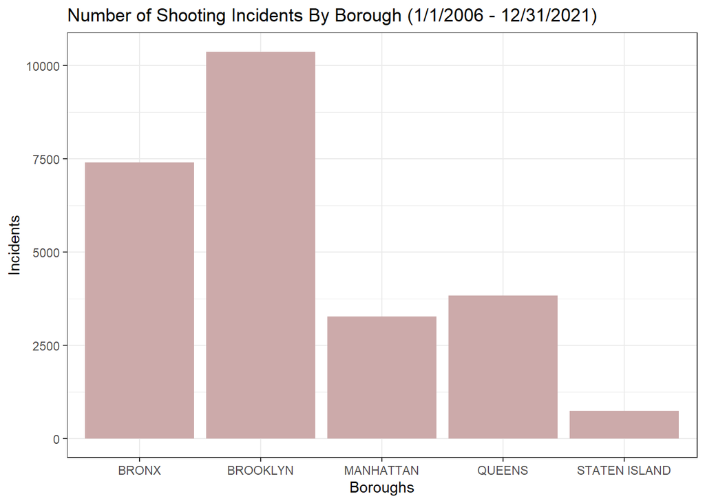

```r
nypd2 %>%
  ggplot(aes(BORO)) +
  geom_bar(fill = "#ccaaaa") +
  theme_bw() +
  labs(x = "Boroughs",
       y = "Incidents",
       title = "Number of Shooting Incidents By Borough (1/1/2006 - 12/31/2021)")
```

Now lets take a look at each Borough over time.

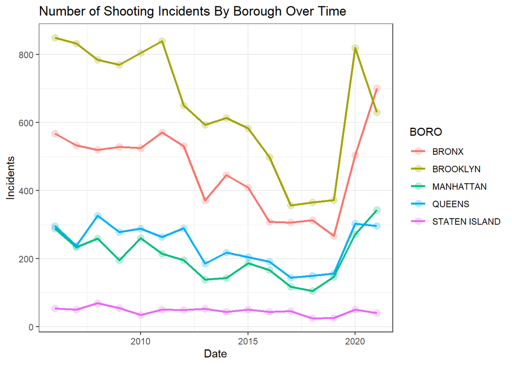

```r
options(dplyr.summarise.inform = FALSE)

yearly <- nypd2 %>%
  mutate(year= year(OCCUR_DATE)) %>%
  group_by(BORO, year) %>%
  summarise(total=n())

yearly %>%
  ggplot(aes(year, total, colour = BORO )) +
  geom_point(size = 3, alpha = .25) +
  geom_line(linewidth = 1) +
  theme_bw() +
  labs(x = "Date",
       y = "Incidents",
       title = "Number of Shooting Incidents By Borough Over Time")
```

Lets take a look at how it breaks down for perp age group with the *UNKNOWN* filtered out.

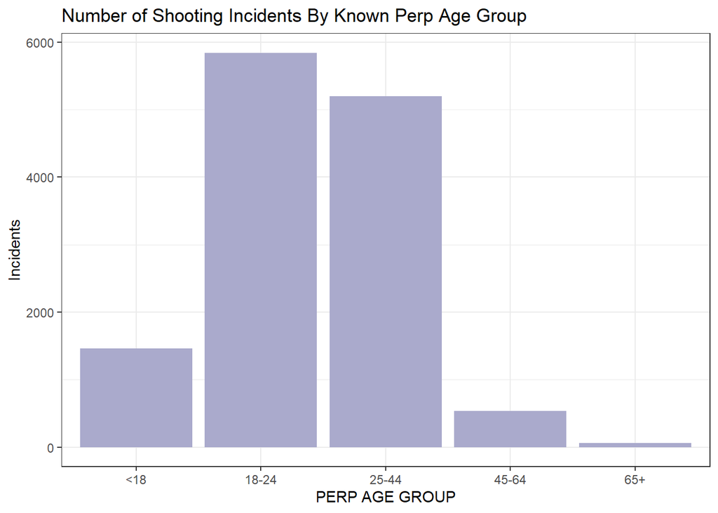

```r
nypd2 %>%
  filter(PERP_AGE_GROUP != "UNKNOWN") %>%
  ggplot(aes(PERP_AGE_GROUP)) +
  geom_bar(fill = "#aaaacc") +
  theme_bw() +
  labs(x = "PERP AGE GROUP",
       y = "Incidents",
       title = "Number of Shooting Incidents By Known Perp Age Group")
```

# Analysis

Looking at the graphs, we can see that Brooklyn has historically, given the time period we are analyzing here, had the highest shooting incidents. We can see that in 2020 the shooting incident rate goes up quite a bit. The numbers are near all time highs for the time period studied. This is the same time the pandemic hit. It would be great to get some data to correlate with to see what else was going on in 2020. A heatmap would really bring this data out.

Having population numbers for each borough over this time period would be great so we can see how the population changed with this data.

I did shy away from doing analysis by race or sex as that can be a sensitive topic that I would to get more training on before I try and approach it in a public manner.

# Conclusion

All of the data is reported by the precinct. Since I have no control over how that data is reported, I am at the mercy of each person that files a report that they do so *without any personal bias*. There is a lot of missing data and this can lead to misrepresentation of the data causing a bias in the result.

I have an unfamiliarity with the different boroughs in New York. All I really know about the population and culture of each borough is what I have seen in the news or in a movie. This is a *major personal bias* that I will have to overcome.

If I had more time, I would love to take a look and see how each precinct compares to each other. Do some precincts report more accurate information than others? How does the data break down when compared over the different age groups present in the data? How does race look when analyzed?

Overall I really enjoyed this assignment. It allowed me to explore a lot of different things that someone in the Data Science field will do in the day to day routine. I am looking forward to seeing where this leads as more concepts and knowledge are added to the pool.